# Final Project - Part 1: Creating Training Dataset

## Submitted by:

- Roey Gilor
- Iris Grabov

## Introduction

In this notebook, we construct a high-quality object detection dataset based on the Flickr image dataset, using the Florence-2 vision-language model. The goal is to prepare data suitable for training a lightweight object detection model (YOLOv8) on edge devices.

The dataset is built in compliance with the course assignment requirements:

- Bounding boxes are created for the classes: `person` and `pet` (union of `dog`, `cat`, and `horse`)
- Images are split into training and validation sets
- Annotations are converted to the YOLO format
- The final dataset is structured for direct compatibility with the Ultralytics YOLOv8 training framework

This part of the project lays the foundation for training and evaluating the detection model in the next phase.

# 1. Imports

```python
import os
os.environ['TF_CPP_MIN_LOG_LEVEL'] = '3'  # Suppress TensorFlow warnings

from transformers import AutoProcessor, AutoModelForCausalLM  # Loads the Florence-2 model and processor for vision-language inference
from PIL import Image  # Image loading and manipulation
import requests  # Downloading files or images from URLs (if needed)
import copy  # Deep copying Python objects
import torch  # PyTorch for tensor operations and model inference
from tqdm import tqdm  # Progress bars for loops
import random  # Random number generation for sampling or shuffling
import json  # Reading and writing annotation files in JSON format
from pathlib import Path  # Filesystem path handling (platform-independent)
import shutil  # File and folder copying/moving
from collections import defaultdict  # Dictionary with default values for list aggregation
import matplotlib.pyplot as plt  # Plotting and visualizations
import numpy as np  # Numerical operations and array handling
import matplotlib.patches as patches  # Drawing bounding boxes on image plots
```

[output not shown]

```python
# Set up inline plotting
%matplotlib inline
```

**. Installations to execute florence model successfully**

- !pip install transformers==4.49.0 flash-attn --no-build-isolation
  - Installs transformers v4.49.0 and flash-attn.
  - --no-build-isolation allows using global dependencies during build (useful for compatibility).
- !pip uninstall flash-attn -y
  - Automatically uninstalls flash-attn without asking for confirmation (-y flag).

```python
!pip install -U transformers
```

```python
!pip install transformers==4.49.0 flash-attn --no-build-isolation
```

[output not shown]

```python
!pip uninstall flash-attn -y
```

```
Found existing installation: flash_attn 2.8.0.post2
Uninstalling flash_attn-2.8.0.post2:
  Successfully uninstalled flash_attn-2.8.0.post2
```

```python
!pip install --upgrade transformers --quiet
```

## Loading Flickr Images

We begin by collecting all available Flickr30k images from the dataset attached via the Kaggle input panel.  
These images will be used as the base for annotation using Florence-2.

We use `Pathlib` to list all `.jpg` files inside the dataset directory, and store them in a list called `all_images`, which will be iterated over in the next steps.

```python
from pathlib import Path

# Define the directory where the images are located
image_dir = Path("/kaggle/input/flickr-image-dataset/flickr30k_images/flickr30k_images")

# Collect all .jpg files into a list
all_images = sorted([p for p in image_dir.glob("*.jpg")])

print(f"Found {len(all_images)} images.")
```

```
Found 31783 images.
```

## Visualizing the First Image and Its Generated Caption

```
✅ Loaded columns: ['image_name', 'comment_number', 'comment']
```

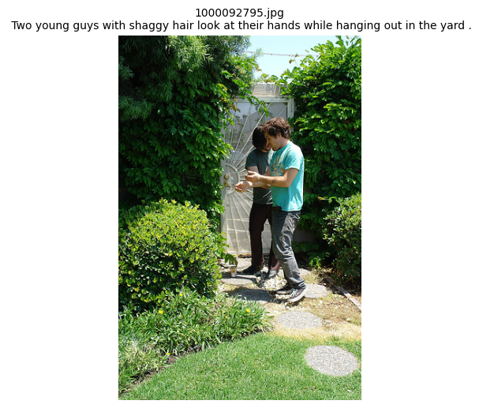

```python
import pandas as pd
from PIL import Image
import matplotlib.pyplot as plt

# Correct CSV load using pipe separator
csv_path = "/kaggle/input/flickr-image-dataset/flickr30k_images/results.csv"
results_df = pd.read_csv(csv_path, sep="|")

# Clean up column names (strip spaces)
results_df.columns = results_df.columns.str.strip()

# Check final column names
print("✅ Loaded columns:", results_df.columns.tolist())

# Get the first image from our dataset
first_image_path = all_images[0]
image = Image.open(first_image_path)
image_name = first_image_path.name

# Filter rows matching the current image
matching_rows = results_df[results_df["image_name"] == image_name]

# Get the first available caption
caption = matching_rows["comment"].values[0] if not matching_rows.empty else "Caption not found."

# Display image and caption
plt.figure(figsize=(8, 6))
plt.imshow(image)
plt.axis("off")
plt.title(f"{image_name}\n{caption}", fontsize=10)
plt.show()
```

## Loading Florence-2 on GPU

We load the Florence-2 model and its processor using HuggingFace Transformers.  
Since we are running in a Kaggle environment with GPU enabled, we move the model to the GPU using `.cuda()` for faster inference performance.

This setup allows us to run vision-language inference at scale over the Flickr30k dataset.

```python
from transformers import AutoProcessor, AutoModelForCausalLM

# Load Florence-2 model and processor
model_id = "microsoft/Florence-2-large"
processor = AutoProcessor.from_pretrained(model_id, trust_remote_code=True)
model = AutoModelForCausalLM.from_pretrained(model_id, trust_remote_code=True).eval().cuda()
```

```
A new version of the following files was downloaded from https://huggingface.co/microsoft/Florence-2-large:
- processing_florence2.py
. Make sure to double-check they do not contain any added malicious code. To avoid downloading new versions of the code file, you can pin a revision.
```

```
A new version of the following files was downloaded from https://huggingface.co/microsoft/Florence-2-large:
- configuration_florence2.py
. Make sure to double-check they do not contain any added malicious code. To avoid downloading new versions of the code file, you can pin a revision.
```

```
A new version of the following files was downloaded from https://huggingface.co/microsoft/Florence-2-large:
- modeling_florence2.py
. Make sure to double-check they do not contain any added malicious code. To avoid downloading new versions of the code file, you can pin a revision.
```

## Automatic Object Annotation with Florence-2 and YOLOv8 Formatting

We use the Florence-2 model to automatically annotate each image with object bounding boxes.  
To ensure high-quality training data for our YOLOv8 model, we apply a series of constraints known as **degrees of freedom**.

### Goal

Generate structured, YOLOv8-compatible annotations for only the relevant classes:

- `person`
- `pet` (union of `dog`, `cat`, `horse`)

### Florence-2 Inference

The model generates predictions using a visual-language prompt (e.g., `<OD>`).  
We post-process these predictions to extract:

- Label name
- Bounding box in pixel coordinates